Tarea 3 - Estadisticas Descriptivas por Variable Cualitativa

Por: Cesar Omar Lopez Arteaga

Febrero 2024

# Pregunta 1

Considerando 131 pacientes con depresión y 132 sin depresión, calcular riesgo y momio y comentar resultados.

```r
# Ingreso de datos y calculos
depresivos <- c(131,132) # Ingreso de datos
nombres <- c("Pacientes Depresivos","Pacientes No Depresivos") # etiquetas
names(depresivos) <- nombres # se utiliza para establecer nombres a las columnas
n <- sum(depresivos) # tamaño muestra
frecuencias <- depresivos/n # frecuencia de los datos
```

```r
# Creacion de la tabla de las Estadisticas Descriptivas
tab <- rbind(t(depresivos),t(frecuencias)) # tabla de salida creada
rownames(tab) <- c("números","frecuencia") # nombres de kas filas
round(tab,3) # salida rondeada de la tabla creada
```

```
##            Pacientes Depresivos Pacientes No Depresivos
## números                 131.000                 132.000
## frecuencia                0.498                   0.502
```

```r
# Calculo del Riesgo
noquote(paste0("riesgo = ", round(depresivos[1]/n,3)))
```

```
## [1] riesgo = 0.498
```

```r
# Calculo de Momio
noquote(paste0("momio = ", round(depresivos[1]/depresivos[2],3)))
```

```
## [1] momio = 0.992
```

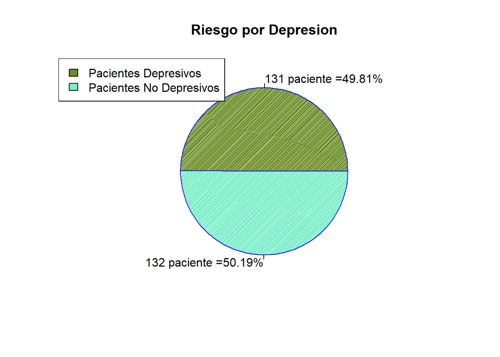

```r
# Grafico Circular
nompie <- paste(nombres,round(frecuencias,3),sep=" ") # etiquetas pie
pie(frecuencias,
    labels = paste0(depresivos," paciente =",round(100*frecuencias/sum(frecuencias),2),"%"),
    col=c("#698B22","#76EEC6"), #definicion de color en hexadecimal
    border = "blue",  # Color del borde de las porciones
    density = 75,
    init.angle=0, # Ángulo inicial
    angle = 45, # Ángulo de inclinación de las etiquetas
    main="Riesgo por Depresion")

legend("topleft",
       legend = nombres,
       fill = c("#698B22","#76EEC6"))
```

Segun los resultado, el riesgo que un paciente tenga depresion es del 49.8 %. El momio indica que las personas que desarrollan depresion tienen aproximadamente 0.992 veces probabilidad de desarrollar depresion en comparación con los pacientes que no desarrollan depresion.

# Pregunta 2

Considerando 907 creyentes en una vida post-muerte y 220 que no creen, calcular riesgo y momio y comentar resultados.

```r
# Ingreso de datos y calculos
creyente <- c(907,220) # Ingreso de datos
nombres <- c("Creyentes de la vida Post muerte","No Creyentes de la vida Post muerte") # etiquetas
names(creyente) <- nombres # se utiliza para establecer nombres a las columnas
n <- sum(creyente) # tamaño muestra
frecuencias <- creyente/n # frecuencia de los datos
```

```r
# Creacion de la tabla de las Estadisticas Descriptivas
tab <- rbind(t(creyente),t(frecuencias)) # tabla de salida creada
rownames(tab) <- c("números","frecuencia") # nombres de kas filas
round(tab,3) # salida rondeada de la tabla creada
```

```
##            Creyentes de la vida Post muerte No Creyentes de la vida Post muerte
## números                             907.000                             220.000
## frecuencia                            0.805                               0.195
```

```r
# Calculo del Riesgo
noquote(paste0("riesgo = ", round(creyente[1]/n,3)))
```

```
## [1] riesgo = 0.805
```

```r
# Calculo de Momio
noquote(paste0("momio = ", round(creyente[1]/creyente[2],3)))
```

```
## [1] momio = 4.123
```

[figure not shown]

```r
# Grafico Circular
nompie <- paste(nombres,round(frecuencias,3),sep=" ") # etiquetas pie
pie(frecuencias,
    labels = paste0(creyente," personas =",round(100*frecuencias/sum(frecuencias),2),"%"),
    col=c("#9ACD32","#7D26CD"), #definicion de color en hexadecimal
    border = "red",  # Color del borde de las porciones
    density = 75,
    init.angle=0, # Ángulo inicial
    angle = 45, # Ángulo de inclinación de las etiquetas
    main="Riesgo por Depresion")

legend("topright",
       legend = nombres,
       fill = c("#9ACD32","#7D26CD"))
```

Segun los resultado, el riesgo que una persona crea en la vida post muerte es del 80.5 %. El momio indica que las personas que creen la vida post muerte tiene aproximadamente 4.123 veces mas probabilidad con respecto de las personas que no creen en la vida post muerte.

# Pregunta 3

Completar la declaración de factores para los caracteres de Pielescuero y calcular distribución, frecuencias relativas, modas y entropías.

```r
# Instala de readxl
install.packages("readxl",repos = "https://cloud.r-project.org/")
```

```r
# Carga la librería readxl
library(readxl)
```

```r
# Especificar la ruta del archivo Excel
ruta_archivo <- "G:/R IMCA/TAREA 3/DESCARGAS_DATA/Pielescuero.xlsx"

# Leer el archivo Excel
data <- read_excel(ruta_archivo)
```

Se muestra la estructura de la data y se muestra los primeros 15 valores de la tabla

```r
# Verificar la estructura de los datos
str(data)
```

```
## tibble [173 × 5] (S3: tbl_df/tbl/data.frame)
##  $ Exportacion : num [1:173] 1 2 1 1 1 1 1 1 1 2 ...
##  $ Tamano      : num [1:173] 1 1 1 1 1 1 1 1 1 1 ...
##  $ Financiacion: num [1:173] 2 2 2 2 2 2 2 2 2 2 ...
##  $ Zona        : num [1:173] 2 3 2 2 1 3 3 3 1 1 ...
##  $ Actividad   : num [1:173] 4 3 3 3 3 3 3 3 4 3 ...
```

```r
# Visualizar los primeros 15 registros de los datos
head(data,n=15)
```

| Exportacion | Tamano | Financiacion | Zona | Actividad |
| --- | --- | --- | --- | --- |
| 1 | 1 | 2 | 2 | 4 |
| 2 | 1 | 2 | 3 | 3 |
| 1 | 1 | 2 | 2 | 3 |
| 1 | 1 | 2 | 2 | 3 |
| 1 | 1 | 2 | 1 | 3 |
| 1 | 1 | 2 | 3 | 3 |
| 1 | 1 | 2 | 3 | 3 |
| 1 | 1 | 2 | 3 | 3 |
| 1 | 1 | 2 | 1 | 4 |
| 2 | 1 | 2 | 1 | 3 |

[output cut: 5 more lines]

Se instala el paquete DescTools y luego se cargara la liberia, esto para el calculo de la moda.

```r
# Instalar el paquete para el calculo de moda
install.packages("DescTools",repos = "https://cloud.r-project.org/")
```

```r
# Cargar el paquete para el calculo de la moda
library(DescTools)
```

Se procedera ha hacer los calculos por variable, para lo cual se calculara las frecuencias, frecuencias relativas, entropia y moda. Se muestra a continuacion el codigo paara la generacion automatica de los calculos.

```
## [1] ---------------------------------------------------------------------
##   frecuencia frecuencia_Relativa
## 1        129           0.7456647
## 2         44           0.2543353
## [1] Entropia total de la variable Exportacion es:
## [1] 0.8180773
## [1] La moda de Exportacion es:
## [1] 1
## attr(,"freq")
## [1] 129
```

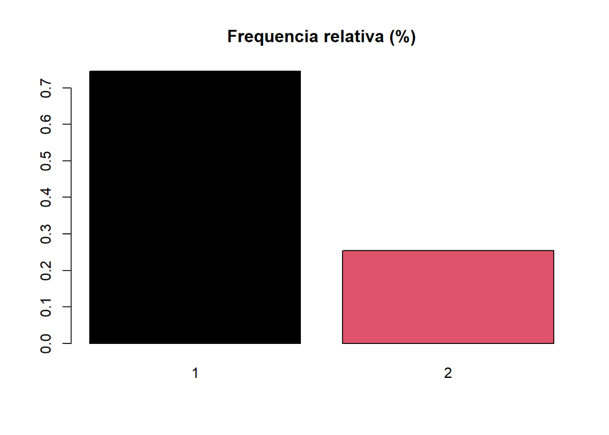

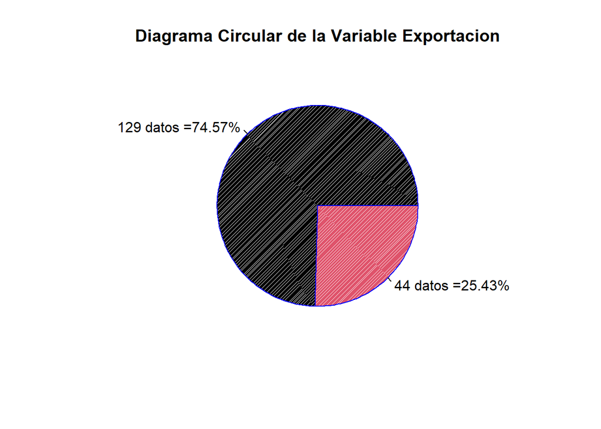

```
## [1] ---------------------------------------------------------------------
##   frecuencia frecuencia_Relativa
## 1         53           0.3063584
## 2         93           0.5375723
## 3         27           0.1560694
## [1] Entropia total de la variable Tamano es:
## [1] 1.422469
## [1] La moda de Tamano es:
## [1] 2
## attr(,"freq")
## [1] 93
```

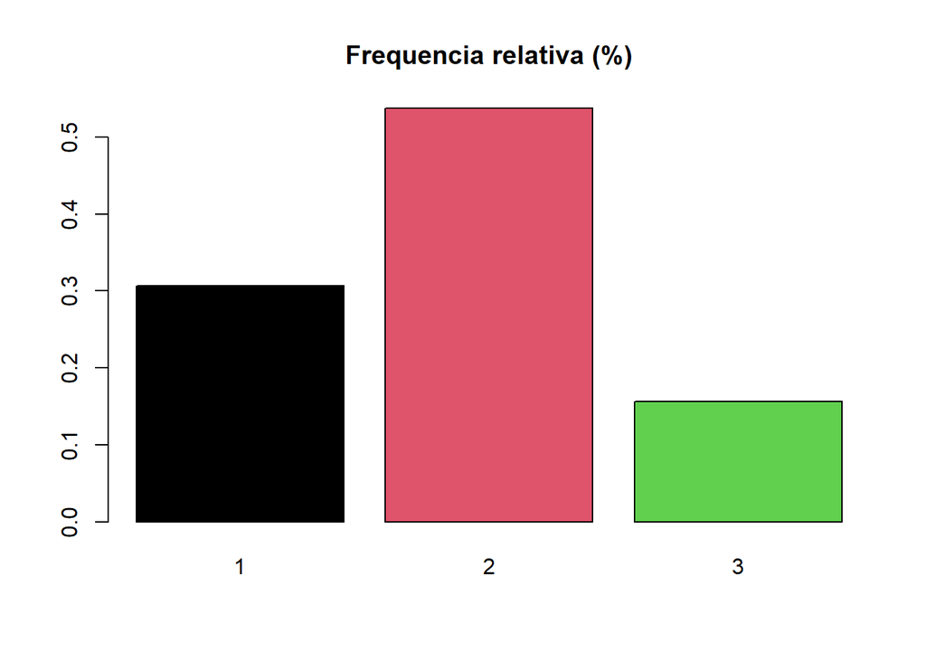

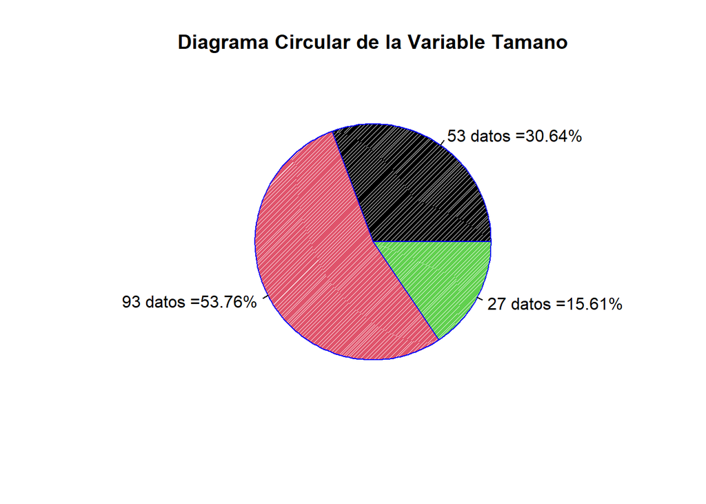

```
## [1] ---------------------------------------------------------------------
##   frecuencia frecuencia_Relativa
## 1         53           0.3063584
## 2        120           0.6936416
## [1] Entropia total de la variable Financiacion es:
## [1] 0.888925
## [1] La moda de Financiacion es:
## [1] 2
## attr(,"freq")
## [1] 120
```

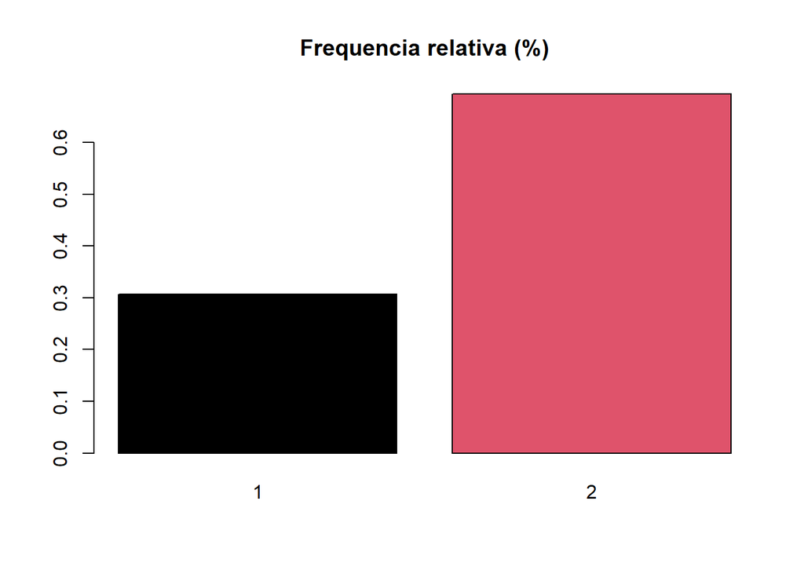

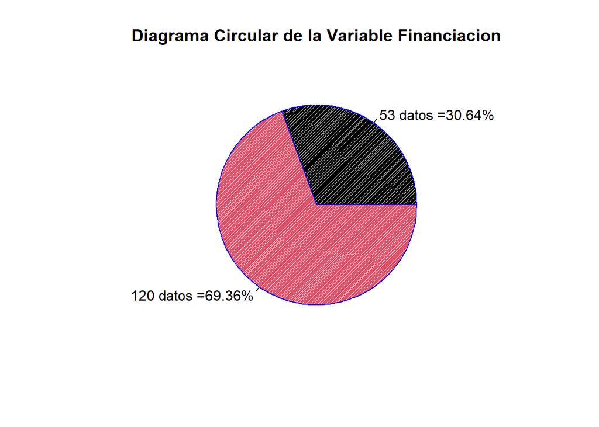

```
## [1] ---------------------------------------------------------------------
##   frecuencia frecuencia_Relativa
## 1         43           0.2485549
## 2         42           0.2427746
## 3         88           0.5086705
## [1] Entropia total de la variable Zona es:
## [1] 1.491063
## [1] La moda de Zona es:
## [1] 3
## attr(,"freq")
## [1] 88
```

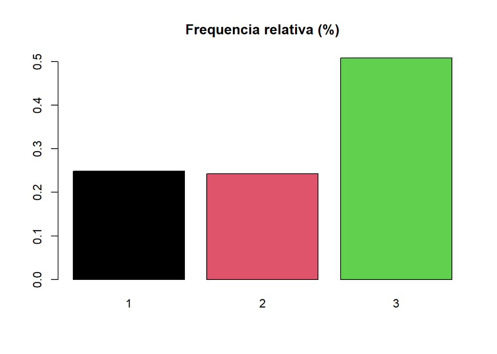

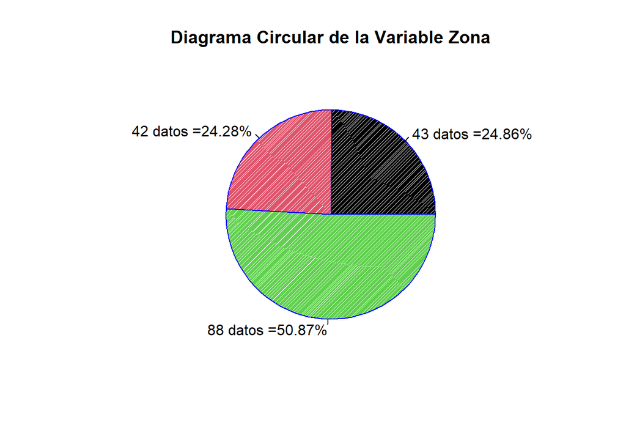

```
## [1] ---------------------------------------------------------------------
##   frecuencia frecuencia_Relativa
## 1         46          0.26589595
## 2         62          0.35838150
## 3         54          0.31213873
## 4         11          0.06358382
## [1] Entropia total de la variable Actividad es:
## [1] 1.815775
## [1] La moda de Actividad es:
## [1] 2
## attr(,"freq")
## [1] 62
```

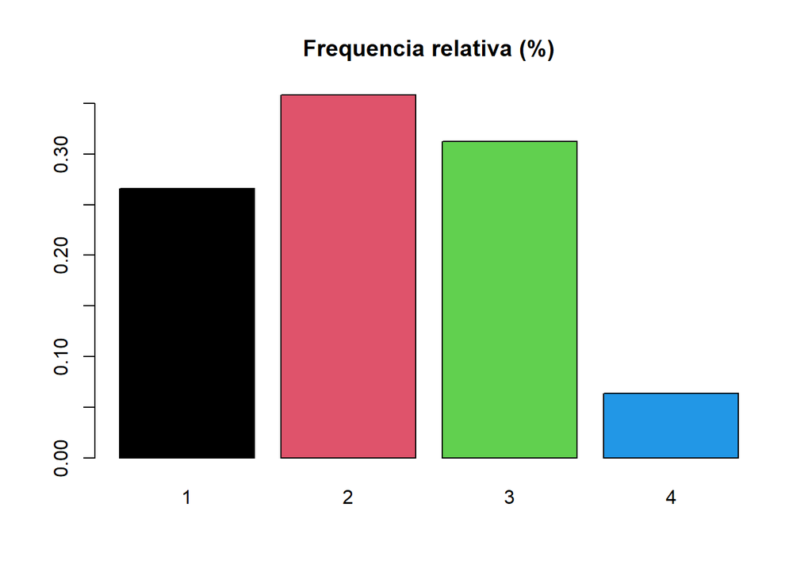

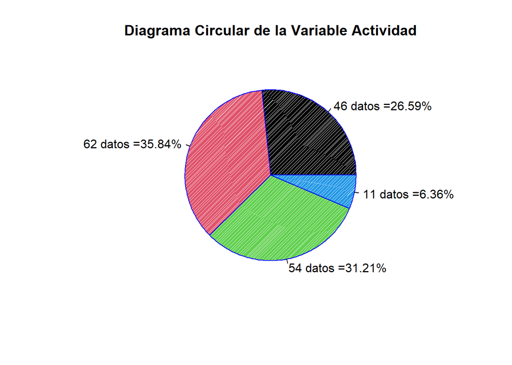

```r
#Calculo de las frecuencias Absolutas
nombres<-colnames(data)
for(i in 1:ncol(data)){
  print(quote=FALSE,"--------------------------------------------------------------------- ")

  # Calculo de la frecuencia de cada variable
  frecuencia<-eval(parse(text = paste0("table(data$",nombres[i],")")))

  # Calculo de la frecuencia relativa de cada variable
  frecuencia_Relativa<-frecuencia/sum(frecuencia)

  # Calculo de la Entropia
  h = -sum(frecuencia_Relativa*log(frecuencia_Relativa,2))

  # Calculo de la moda
  moda<-eval(parse(text = paste0("Mode(data$",nombres[i],")")))

  # Impresion de las frecuencias
  print(cbind(frecuencia,frecuencia_Relativa))

  # Impresion de la Entropia
  print(quote=FALSE, paste0(prefix="Entropia total de la variable ",nombres[i]," es: "))
  print(h)

  # Impresion de la Moda
  print(paste0("La moda de ",nombres[i]," es: "),quote=FALSE)
  print(moda)

  # Gráfico de barras
  barplot(frecuencia_Relativa,
      main = "Frequencia relativa (%)",
      col = c(1:ncol(data)))

  # Grafico Circular
  nompie <- paste(nombres,round(frecuencia,3),sep=" ") # etiquetas pie
  pie(frecuencia,
      labels = paste0(frecuencia," datos =",round(100*frecuencia/sum(frecuencia),2),"%"),
      col=c(1:ncol(data)), #definicion de color en hexadecimal
      border = "blue",  # Color del borde de las porciones
      density = 80,
      init.angle=0, # Ángulo inicial
      angle = 45, # Ángulo de inclinación de las etiquetas
      main=paste0("Diagrama Circular de la Variable ",nombres[i]))
}
```

# Pregunta 4

Bajar el archivo Snee.csv desde internet utilizando la dirección http://www.camiz.it/sergio/Universita/Dati/ y cargar-lo en R. Trata-se de Color de ojos y Color de pelo de 592 Alumnos de la Universidad de Delaware en 1974.

Se bajara el archivo Snee.csv, luego se cargara el archivo y se muestrara la estructura de la data, luego se muestra los primeros 15 valores de la tabla

```r
# Leer un archivo CSV y almacenar los datos en un objeto llamado 'datos'
df <- read.csv( "G:/R IMCA/TAREA 3/DESCARGAS_DATA/Snee.csv")

# Verificar la estructura de los datos
str(df)
```

```
## 'data.frame':    592 obs. of  2 variables:
##  $ Colore_occhi  : int  1 1 1 1 1 1 1 1 1 1 ...
##  $ Colore_capelli: int  1 1 1 1 1 1 1 1 1 1 ...
```

```r
# Visualizar los primeros 15 registros de los datos
head(df,n=15)
```

|  | Colore_occhi | Colore_capelli |
| --- | --- | --- |
| 1 | 1 | 1 |
| 2 | 1 | 1 |
| 3 | 1 | 1 |
| 4 | 1 | 1 |
| 5 | 1 | 1 |
| 6 | 1 | 1 |
| 7 | 1 | 1 |
| 8 | 1 | 1 |
| 9 | 1 | 1 |
| 10 | 1 | 1 |

[output cut: 5 more lines]

# Pregunta 5

Comenzamos a transformar el dataframe de la columna Colore_occhi con las reglas establecidas, luego visualizamos como va quedando el dataframe(df).

```r
df$Colore_occhi[df$Colore_occhi == 1] <- "Pardo Oscuro"
df$Colore_occhi[df$Colore_occhi == 2] <- "Pardo Claro"
df$Colore_occhi[df$Colore_occhi == 3] <- "Verde"
df$Colore_occhi[df$Colore_occhi == 4] <- "Azul"
df
```

| Colore_occhi | Colore_capelli |
| --- | --- |
| Pardo Oscuro | 1 |
| Pardo Oscuro | 1 |
| Pardo Oscuro | 1 |
| Pardo Oscuro | 1 |
| Pardo Oscuro | 1 |
| Pardo Oscuro | 1 |
| Pardo Oscuro | 1 |
| Pardo Oscuro | 1 |
| Pardo Oscuro | 1 |
| Pardo Oscuro | 1 |

[output cut: 582 more lines]

A continuaacion se transformar el dataframe de la columna Colore_capelli con las reglas establecidas, luego visualizamos como va quedando el dataframe(df).

```r
df$Colore_capelli[df$Colore_capelli == 1] <- "Negro"
df$Colore_capelli[df$Colore_capelli == 2] <- "Pardo"
df$Colore_capelli[df$Colore_capelli == 3] <- "Rojo"
df$Colore_capelli[df$Colore_capelli == 4] <- "Rubio"
df
```

| Colore_occhi | Colore_capelli |
| --- | --- |
| Pardo Oscuro | Negro |
| Pardo Oscuro | Negro |
| Pardo Oscuro | Negro |
| Pardo Oscuro | Negro |
| Pardo Oscuro | Negro |
| Pardo Oscuro | Negro |
| Pardo Oscuro | Negro |
| Pardo Oscuro | Negro |
| Pardo Oscuro | Negro |
| Pardo Oscuro | Negro |

[output cut: 582 more lines]

# Pregunta 6

Guardar en un nuevo archivo.

```r
# Utilizando write.csv2()
write.csv(df, file = "G:/R IMCA/TAREA 3/DESCARGAS_DATA/nuevo_Snee.csv", row.names = FALSE)
```

# Pregunta 7

Calcular las distribuciones, la moda y la entropía de los dos caracteres y hacer gráficos circulares.

```r
# Leer un archivo CSV y almacenar los datos en un objeto llamado 'ndf'
ndf <- read.csv( "G:/R IMCA/TAREA 3/DESCARGAS_DATA/nuevo_Snee.csv")

# Verificar la estructura de los datos
str(ndf)
```

```
## 'data.frame':    592 obs. of  2 variables:
##  $ Colore_occhi  : chr  "Pardo Oscuro" "Pardo Oscuro" "Pardo Oscuro" "Pardo Oscuro" ...
##  $ Colore_capelli: chr  "Negro" "Negro" "Negro" "Negro" ...
```

```r
# Visualizar los primeros 15 registros de los datos
head(ndf,n=15)
```

|  | Colore_occhi | Colore_capelli |
| --- | --- | --- |
| 1 | Pardo Oscuro | Negro |
| 2 | Pardo Oscuro | Negro |
| 3 | Pardo Oscuro | Negro |
| 4 | Pardo Oscuro | Negro |
| 5 | Pardo Oscuro | Negro |
| 6 | Pardo Oscuro | Negro |
| 7 | Pardo Oscuro | Negro |
| 8 | Pardo Oscuro | Negro |
| 9 | Pardo Oscuro | Negro |
| 10 | Pardo Oscuro | Negro |

[output cut: 5 more lines]

```
## [1] ---------------------------------------------------------------------
##              frecuencia frecuencia_Relativa
## Azul                215           0.3631757
## Pardo Claro          93           0.1570946
## Pardo Oscuro        220           0.3716216
## Verde                64           0.1081081
## [1] Entropia total de la variable Colore_occhi es:
## [1] 1.827862
## [1] La moda de Colore_occhi es:
## [1] "Pardo Oscuro"
## attr(,"freq")
## [1] 220
```

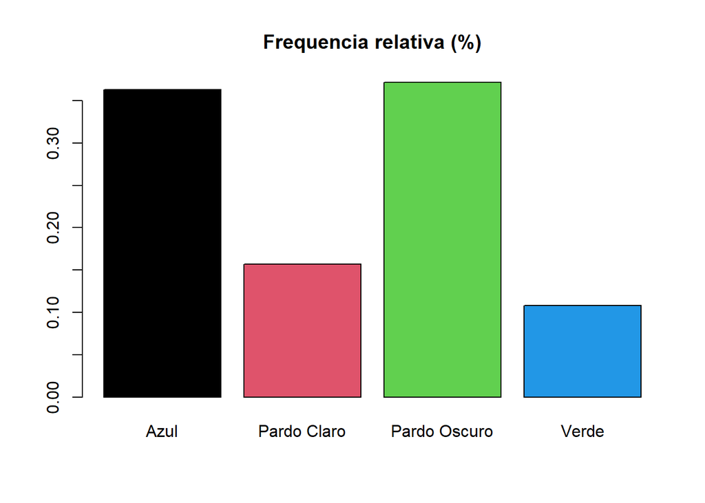

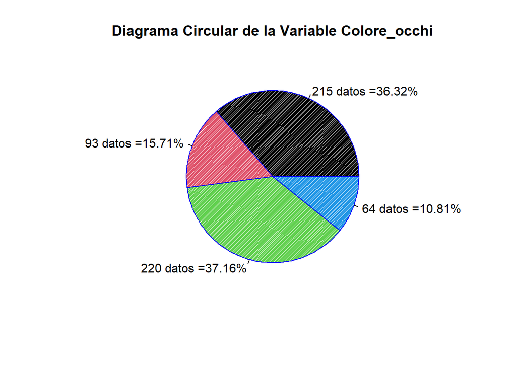

```
## [1] ---------------------------------------------------------------------
##       frecuencia frecuencia_Relativa
## Negro        108           0.1824324
## Pardo        286           0.4831081
## Rojo          71           0.1199324
## Rubio        127           0.2145270
## [1] Entropia total de la variable Colore_capelli es:
## [1] 1.798227
## [1] La moda de Colore_capelli es:
## [1] "Pardo"
## attr(,"freq")
## [1] 286
```

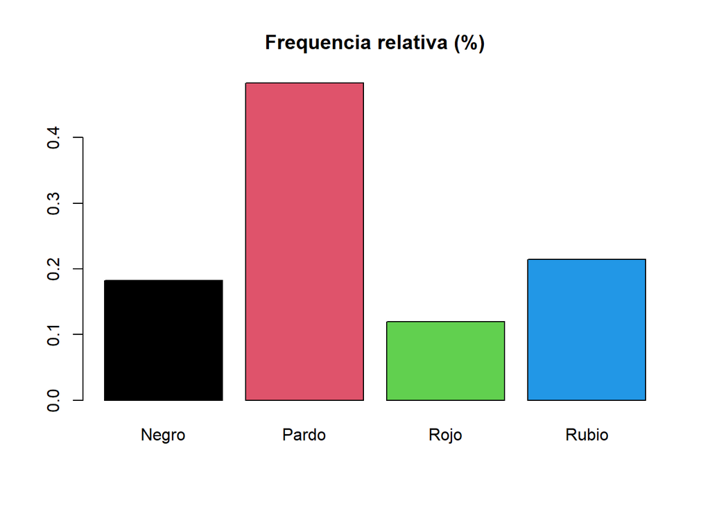

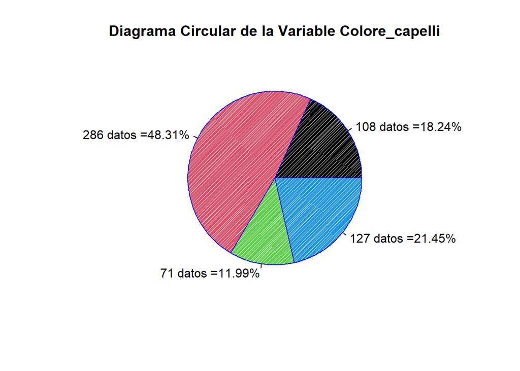

```r
#Calculo de las frecuencias Absolutas
nombres<-colnames(ndf)
for(i in 1:ncol(ndf)){
  print(quote=FALSE,"--------------------------------------------------------------------- ")

  # Calculo de la frecuencia de cada variable
  frecuencia<-eval(parse(text = paste0("table(ndf$",nombres[i],")")))

  # Calculo de la frecuencia relativa de cada variable
  frecuencia_Relativa<-frecuencia/sum(frecuencia)

  # Calculo de la Entropia
  h = -sum(frecuencia_Relativa*log(frecuencia_Relativa,2))

  # Calculo de la moda
  moda<-eval(parse(text = paste0("Mode(ndf$",nombres[i],")")))

  # Impresion de las frecuencias
  print(cbind(frecuencia,frecuencia_Relativa))

  # Impresion de la Entropia
  print(quote=FALSE, paste0(prefix="Entropia total de la variable ",nombres[i]," es: "))
  print(h)

  # Impresion de la Moda
  print(paste0("La moda de ",nombres[i]," es: "),quote=FALSE)
  print(moda)

  # Gráfico de barras
  barplot(frecuencia_Relativa,
      main = "Frequencia relativa (%)",
      col = c(1:length(frecuencia)))

  # Grafico Circular
  nompie <- paste(nombres,round(frecuencia,3),sep=" ") # etiquetas pie
  pie(frecuencia,
      labels = paste0(frecuencia," datos =",round(100*frecuencia/sum(frecuencia),2),"%"),
      col=c(1:length(frecuencia)), #definicion de color en hexadecimal
      border = "blue",  # Color del borde de las porciones
      density = 80,
      init.angle=0, # Ángulo inicial
      angle = 45, # Ángulo de inclinación de las etiquetas
      main=paste0("Diagrama Circular de la Variable ",nombres[i]))
}
```

# Pregunta 8

Mejorar los gráficos, con títulos, porcentajes, colores, etc.

Mejoramos los gráficos, con títulos, porcentajes, colores que acontinuacion mostramos el codigo.

```
## [1] ---------------------------------------------------------------------
```

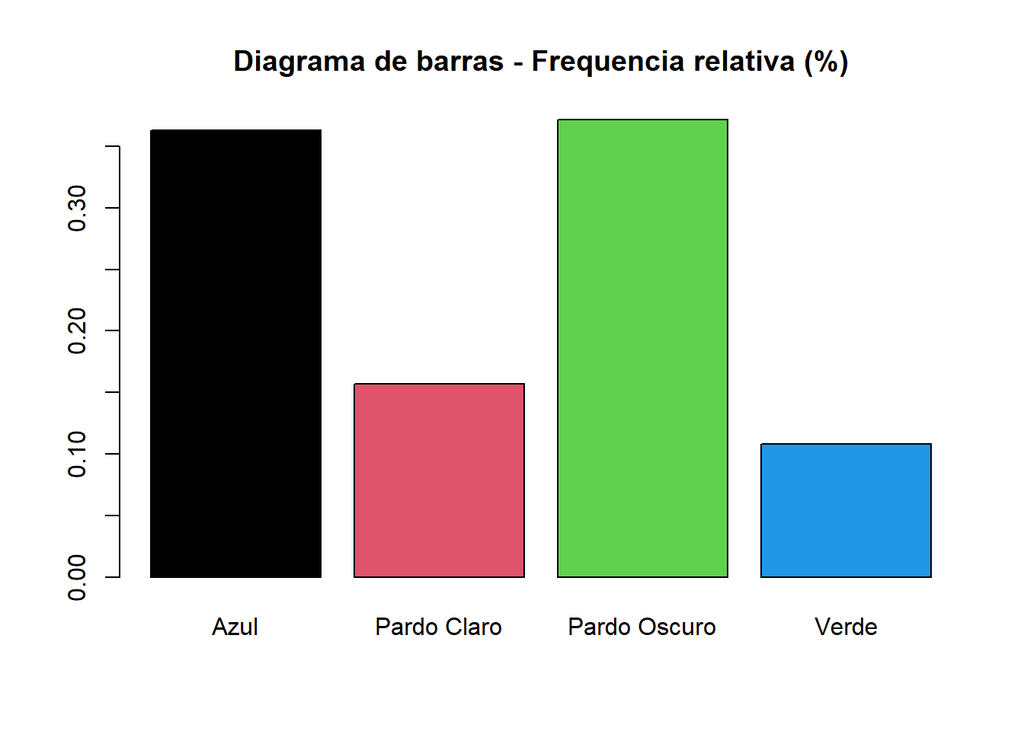

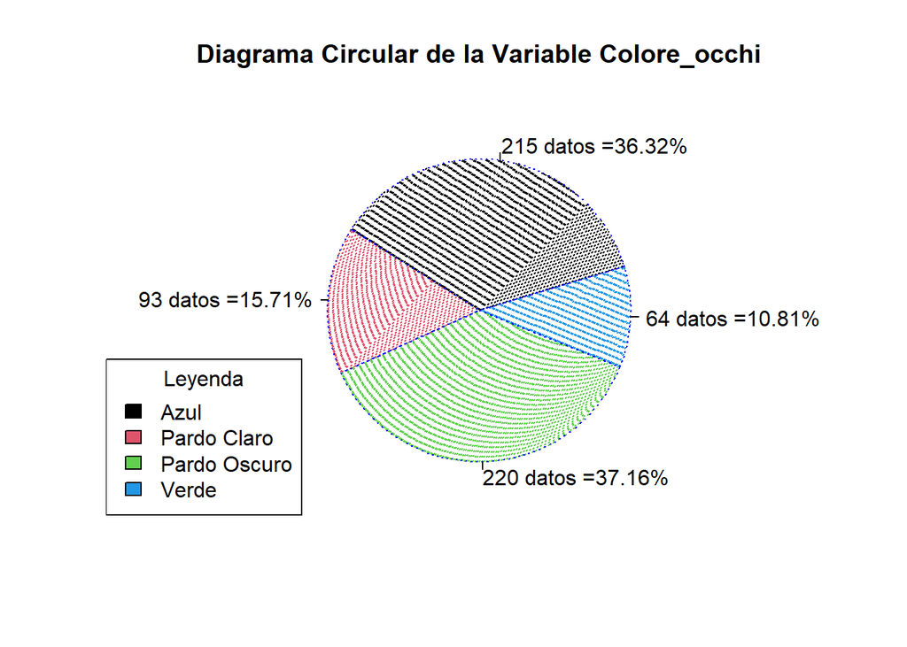

```
## [1] ---------------------------------------------------------------------
```

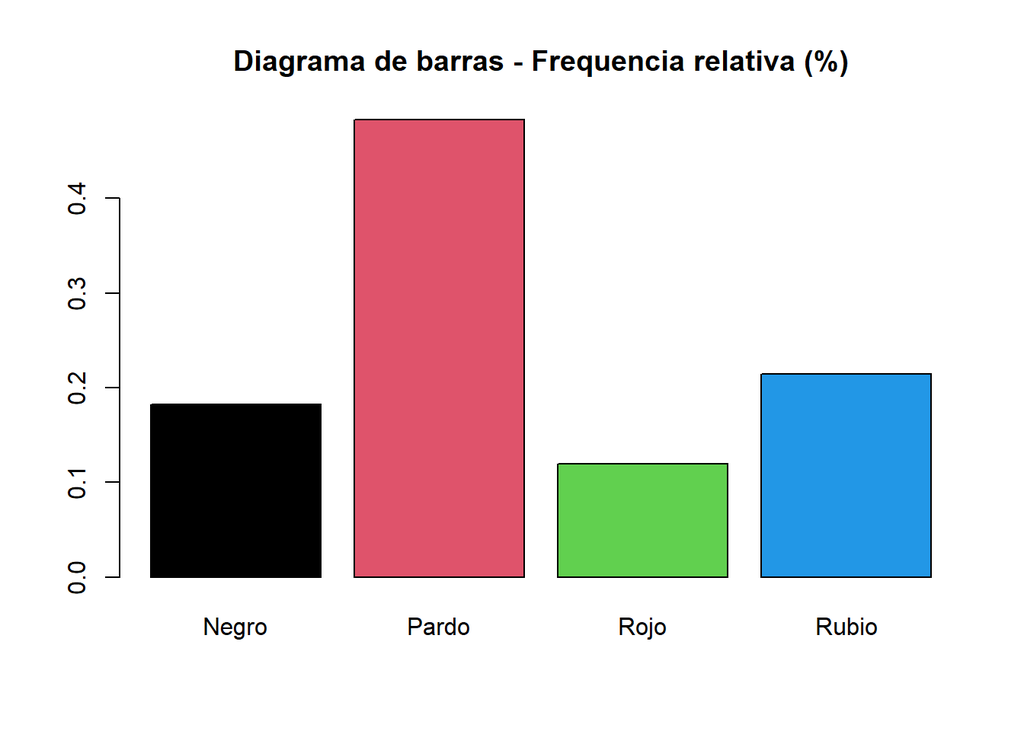

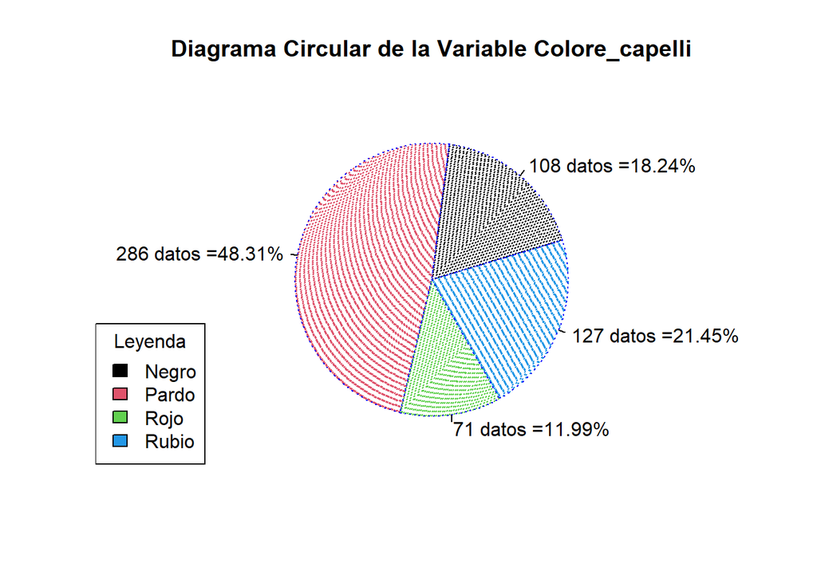

```r
# Leer un archivo CSV y almacenar los datos en un objeto llamado 'ndf'
ndf <- read.csv( "G:/R IMCA/TAREA 3/DESCARGAS_DATA/nuevo_Snee.csv")

#Calculo de las frecuencias Absolutas
nombres<-colnames(ndf)
for(i in 1:ncol(ndf)){
  print(quote=FALSE,"--------------------------------------------------------------------- ")

  # Calculo de la frecuencia de cada variable
  frecuencia<-eval(parse(text = paste0("table(ndf$",nombres[i],")")))

  # Calculo de la frecuencia relativa de cada variable
  frecuencia_Relativa<-frecuencia/sum(frecuencia)

  # Calculo de la Entropia
  h = -sum(frecuencia_Relativa*log(frecuencia_Relativa,2))

  # Calculo de la moda
  moda<-eval(parse(text = paste0("Mode(ndf$",nombres[i],")")))

  # Gráfico de barras
  barplot(frecuencia_Relativa,
      main = "Diagrama de barras - Frequencia relativa (%)",
      col = c(1:length(frecuencia)))

  # Grafico Circular
  nompie <- paste(nombres,round(frecuencia,3),sep=" ") # etiquetas pie
  pie(frecuencia,
      labels = paste0(frecuencia," datos =",round(100*frecuencia/sum(frecuencia),2),"%"),
      col=c(1:length(frecuencia)), #definicion de color en hexadecimal
      border = "blue",  # Color del borde de las porciones
      density = 80,
      init.angle=17, # Ángulo inicial
      angle = 45, # Ángulo de inclinación de las etiquetas
      lty = 3,
      main=paste0("Diagrama Circular de la Variable ",nombres[i]))

  legend("bottomleft",
       title = "Leyenda",
       legend = names(frecuencia),
       fill = c(1:length(frecuencia)))
}
```